# INTRODUCTION

This notebook provide a basic dataset preparation and transformation for object detection. It uses Tensorflow predefined models. These models are further trained to analyse activities such as:

1. being_angry
2. crying
3. drinking
4. eating
5. holding_someone
6. on_stairs
7. sitting_down
8. sleeping
9. standing
10. standing_up
11. walking
12. walking_with_stick

## Resources

- [MODELS](https://github.com/tensorflow/models/tree/master/research/object_detection/models)

  This repository contains a number of different models implemented in TensorFlow. The official models are a collection of example models that use TensorFlow's high-level APIs.The research models are a large collection of models implemented in TensorFlow by researchers.
- [CONFIG FILES](https://github.com/tensorflow/models/tree/master/research/object_detection/samples)

  The samples folder contains code snippets and smaller models that demonstrate features of TensorFlow, including code presented in various blog posts.
- [TF RECORD AND XML TO CSV](https://github.com/datitran/raccoon_dataset)
  1. annotations: contains the xml files in PASCAL VOC format
  2. data: contains the input file for the TF object detection API and the label files (csv)
  3. images: contains the image data in jpg format
  4. training: contains the pipeline configuration file, frozen model and labelmap
  5. a few handy scripts:
     - `generate_tfrecord.py is used to generate the input filesfor the TF API`
     - `xml_to_csv.py is used to convert the xml files into one csv`
  6. a few jupyter notebooks:
     - `draw boxes is used to plot some of the data.`
     - `split labels is used to split the full labels into train and test labels.`

## Chapter 1

## Chapter 2

### TF RECORD GENERATOR

#### From tensorflow/models/

##### Create train data:

`python generate_tfrecord.py --csv_input=data/train_labels.csv --output_path=train.record`

##### Create test data:

`python generate_tfrecord.py --csv_input=data/test_labels.csv --output_path=test.record`

###### Imports

> ```
> from __future__ import division
> from __future__ import print_function
> from __future__ import absolute_import
> import os
> import io
> import pandas as pd
> import tensorflow as tf
> from PIL import Image
> from object_detection.utils import dataset_util
> from collections import namedtuple, OrderedDict
> ```

###### Arguments

> ```
> flags = tf.app.flags
> flags.DEFINE_string('csv_input', '', 'Path to the CSV input')
> flags.DEFINE_string('output_path', '', 'Path to output TFRecord')
> flags.DEFINE_string('image_dir', '', 'Path to images')
> FLAGS = flags.FLAGS
> ```

###### TO-DO: replace this with label map

> ```
> def class_text_to_int(row_label):
>     if row_label == 'Label':
>         return 1
>     else:
>         None
> def split(df, group):
>     data = namedtuple('data', ['filename', 'object'])
>     gb = df.groupby(group)
>     return [data(filename, gb.get_group(x)) for filename, x in zip(gb.groups.keys(), gb.groups)]
> def create_tf_example(group, path):
>     with tf.gfile.GFile(os.path.join(path, '{}'.format(group.filename)), 'rb') as fid:
>         encoded_jpg = fid.read()
>     encoded_jpg_io = io.BytesIO(encoded_jpg)
>     image = Image.open(encoded_jpg_io)
>     width, height = image.size
>     filename = group.filename.encode('utf8')
>     image_format = b'jpg'
>     xmins = []
>     xmaxs = []
>     ymins = []
>     ymaxs = []
>     classes_text = []
>     classes = []
>     for index, row in group.object.iterrows():
>         xmins.append(row['xmin'] / width)
>         xmaxs.append(row['xmax'] / width)
>         ymins.append(row['ymin'] / height)
>         ymaxs.append(row['ymax'] / height)
>         classes_text.append(row['class'].encode('utf8'))
>         classes.append(class_text_to_int(row['class']))
>     tf_example = tf.train.Example(features=tf.train.Features(feature={
>         'image/height': dataset_util.int64_feature(height),
>         'image/width': dataset_util.int64_feature(width),
>         'image/filename': dataset_util.bytes_feature(filename),
>         'image/source_id': dataset_util.bytes_feature(filename),
>         'image/encoded': dataset_util.bytes_feature(encoded_jpg),
>         'image/format': dataset_util.bytes_feature(image_format),
>         'image/object/bbox/xmin': dataset_util.float_list_feature(xmins),
>         'image/object/bbox/xmax': dataset_util.float_list_feature(xmaxs),
>         'image/object/bbox/ymin': dataset_util.float_list_feature(ymins),
>         'image/object/bbox/ymax': dataset_util.float_list_feature(ymaxs),
>         'image/object/class/text': dataset_util.bytes_list_feature(classes_text),
>         'image/object/class/label': dataset_util.int64_list_feature(classes),
>     }))
>     return tf_example
> ```

###### Main

> ```
> def main(_):
>     writer = tf.python_io.TFRecordWriter(FLAGS.output_path)
>     path = os.path.join(FLAGS.image_dir)
>     examples = pd.read_csv(FLAGS.csv_input)
>     grouped = split(examples, 'filename')
>     for group in grouped:
>         tf_example = create_tf_example(group, path)
>         writer.write(tf_example.SerializeToString())
>     writer.close()
>     output_path = os.path.join(os.getcwd(), FLAGS.output_path)
>     print('Successfully created the TFRecords: {}'.format(output_path))
> if __name__ == '__main__':
>     tf.app.run()
> ```

### XML TO CSV

###### Imports

> ```
> import os
> import glob
> import pandas as pd
> import xml.etree.ElementTree as ET
> ```

###### MAIN

> ```
> def main():
>     image_path = os.path.join(os.getcwd(), 'annotations')
>     xml_df = xml_to_csv(image_path)
>     xml_df.to_csv('raccoon_labels.csv', index=None)
>     print('Successfully converted xml to csv.')
> main()
> ```

### Required CSV Format

#### data_file.csv contains the list of all the transformed videos.

#### For Eg.

[output not shown]

## Chapter 3

# **CHAPTER 1**

## Preprocessing Video Files

## Helper Functions

### : Raw Videos

1. Listing Directories in Raw.
2. Appending File names in a list.

```python
import os
from collections import Iterable
def flatten(lis):
     for item in lis:
         if isinstance(item, Iterable) and not isinstance(item, basestring):
             for x in flatten(item):
                 yield x
         else:
             yield item

filenames = []
for files in os.listdir("raw/"):
    filenames.append(files)
print filenames
```

```
['being_angry', 'drinking', 'eating_meal']
```

```python
import subprocess
import os

filenames = []
for files in os.listdir("raw/"):
    filenames.append(files)
print filenames

for files in enumerate(filenames):
    path = str(os.listdir("raw/"+str(files[1])))
    bashCommand1 = 'cd raw/'+str(files[1])+'&& ls && ls | cat -n | while read n f; do mv "$f" `printf v_"'+str(files[1])+'"_%04d.mp4 $n`; done && cd .. && cd ..'
    os.system(bashCommand1)
    #subprocess.call(path+str(files[1])+".sh", shell=True)
```

```
['being_angry', 'drinking', 'eating_meal']
```

## Importing Libraries

```python
#@title Import the necessary modules
# TensorFlow and TF-Hub modules.
import tensorflow as tf
import tensorflow_hub as hub

tf.logging.set_verbosity(tf.logging.ERROR)

# Some modules to help with reading the UCF101 dataset.
import random
import re
import os
import tempfile
import cv2
import numpy as np
from PIL import Image

# Some modules to display an animation using imageio.
import imageio
from IPython import display

import urllib  # requires python3
from urlparse import urljoin
```

## Loading transformed data

### Creating Functions

1. **list_videos** : To list all the video stored in transformed folder.
2. **fetch_video** : To pull all the video.
3. **crop_center** : Cropping function to reduce the size of videos.
4. **load_video** : Function to load video files and extract frames.
5. **animate** : To create gif

```python
#@title Helper functions for the UCF101 dataset

# Utilities to fetch videos from UCF101 dataset
UCF_ROOT = "raw/"
video_list = []
_VIDEO_LIST = []
_CACHE_DIR = tempfile.mkdtemp()

def list_ucf_videos():
  count=0
  """Lists videos available in  dataset."""
  global _VIDEO_LIST
  for folder in range(len(filenames)):
    index = str(os.listdir(UCF_ROOT+filenames[count]+"/"))
    videos = re.findall("(v_[\w_]+\.mp4)", index)
    video_list = sorted(set(videos))
    _VIDEO_LIST.append(video_list)
    count+=1
  return list(flatten(_VIDEO_LIST))

def fetch_ucf_video(video):
  """Fetchs a video and cache into local filesystem."""
  cache_path = os.path.join(_CACHE_DIR, video)
  if not os.path.exists(cache_path):
    urlpath = urljoin(UCF_ROOT, video)
    print("Fetching %s => %s" % (urlpath, cache_path))
    data = urllib.urlopen(urlpath).read()
    open(cache_path, "wb").write(data)
  return data

# Utilities to open video files using CV2
def crop_center_square(frame):
  y, x = frame.shape[0:2]
  min_dim = min(y, x)
  start_x = (x // 2) - (min_dim // 2)
  start_y = (y // 2) - (min_dim // 2)
  return frame[start_y:start_y+min_dim,start_x:start_x+min_dim]

def load_video(path,max_frames=0, resize=(224, 224)):
  cap = cv2.VideoCapture(path)
  frames = []

  try:
    while True:
      ret, frame = cap.read()
      if not ret:
        break
      frame = crop_center_square(frame)
      frame = cv2.resize(frame, resize)
      frame = frame[:, :, [2, 1, 0]]
      success,image = cap.read()

      if( frame != None ):
        image=cv2.resize(image,(224,224), interpolation = cv2.INTER_AREA)

      if (ret != True):
        break
      frames.append(frame)


      if len(frames) == max_frames:
        break
  finally:
    cap.release()
  return np.array(frames) / 255.0

def animate(images):
  converted_images = np.clip(images * 255, 0, 255).astype(np.uint8)
  os.makedirs(str(category))
  imageio.mimsave(str(category)+'/'+str(category)+'.gif', converted_images)
  with open(str(category)+'/'+str(category)+'.gif','rb') as f:
    display.display(display.Image(data=f.read(), height=300))
```

## Categorizing Videos

Function Below categorises videos on the basis of their type.

```python
# Get the list of videos in the dataset.
ucf_videos = list_ucf_videos()
categories = {}
for video in ucf_videos:
    category = video[2:-9]
    #Appending files of same category
    if category not in categories:
        categories[category] = []
    categories[category].append(video)
print("Found %d videos in %d categories." % (len(ucf_videos), len(categories)))

for category, sequences in categories.items():
    summary = ", ".join(sequences[:2])
    print("%-20s %4d videos (%s, ...)" % (category, len(sequences), summary))
```

```
Found 1609 videos in 3 categories.
drinking              510 videos (v_drinking_0001.mp4, v_drinking_0002.mp4, ...)
eating_meal           445 videos (v_eating_meal_0001.mp4, v_eating_meal_0002.mp4, ...)
being_angry           654 videos (v_being_angry_0001.mp4, v_being_angry_0002.mp4, ...)
```

```python
# Get animation of sample video.
#sample_video = load_video(fetch_ucf_video(categories['eating'][2]))
#print("sample_video is a numpy array of shape %s." % str(sample_video.shape))
#animate(sample_video)
print("Preprocessing Completed")
```

```
Preprocessing Completed
```

## Preparing CSVs

#### data_file.csv contains the list of all the transformed videos.

#### For Eg.

[output not shown]

1. Cv2 loads the video files.
2. For all the categories and then all the videos in each category fect and load funch is applied to retrive the frames.
3. Frames are written in data/*category*
4. Details are written in csv file

```python
import os
import math
import cv2
import csv
import shutil

class_names = {}
minor_width   = 10**100  # No image will be bigger than that
major_width   = 0
minor_height  = 10**100  # No image will be bigger than that
major_height  = 0

for category in categories:
    dir = 'data/'+str(category)
    if os.path.exists(dir):
        shutil.rmtree(dir)
    os.makedirs(dir)

data_file = 'data/data_file.csv'
with open(data_file, 'w') as fout:
    fieldnames = ['Label','Category','Subject','FrameNo','Width','Height','Name','Type']
    writer = csv.DictWriter(fout, fieldnames=fieldnames)
    writer.writeheader()
    flag=1
    for category in categories:
        for files in categories[category]:
            video = cv2.VideoCapture("raw/"+category+"/"+files)
            print(video.isOpened())
            framerate = video.get(5)
            while(video.isOpened()):
                frameId = video.get(1)
                success,image = video.read()
                if( image is not None ):
                    image=cv2.resize(image,(224,224), interpolation = cv2.INTER_AREA)
                if (success != True):
                    break
                if (frameId % math.floor(framerate) == 0):
                    filename = "data/"+str(category)+"/"+str(files[2:-4]) + "_image_" + str(int(frameId / math.floor(framerate))+1) + ".jpg"
                    images_folder = "images/"+str(files[2:-4]) + "_image_" + str(int(frameId / math.floor(framerate))+1) + ".jpg"
                    cv2.imwrite(filename,image)
                    cv2.imwrite(images_folder,image)
                    im = Image.open(filename)
                    width, height = im.size
                    #min_width = min(width,minor_width)
                    #max_width = max(width,major_height)
                    #min_height = min(height,minor_height)
                    #max_height = max(height,major_height)
                    writer.writerow({'Label':flag,\
                                     'Category':category,\
                                     'Subject':str(files[-8:-4]),\
                                     'FrameNo':str(int(frameId / math.floor(framerate))+1),\
                                     'Width':width,\
                                     'Height':height,\
                                     'Name':str(str(files[2:-4]) + "_image_" + str(int(frameId / math.floor(framerate))+1) + ".jpg"),\
                                     'Type':'jpg',\
                                    })
                    print(filename)
                    print("Extracted and wrote %d frames." % (len(data_file)))
            video.release()
            print('done')
        class_names.update({flag:category})
        flag+=1
```

```
True
data/drinking/drinking_0001_image_1.jpg
Extracted and wrote 18 frames.
data/drinking/drinking_0001_image_2.jpg
Extracted and wrote 18 frames.
data/drinking/drinking_0001_image_3.jpg
Extracted and wrote 18 frames.
data/drinking/drinking_0001_image_4.jpg
Extracted and wrote 18 frames.
data/drinking/drinking_0001_image_5.jpg
Extracted and wrote 18 frames.
done
True
data/drinking/drinking_0002_image_1.jpg
Extracted and wrote 18 frames.
data/drinking/drinking_0002_image_2.jpg
Extracted and wrote 18 frames.
data/drinking/drinking_0002_image_3.jpg
Extracted and wrote 18 frames.
data/drinking/drinking_0002_image_4.jpg
Extracted and wrote 18 frames.
data/drinking/drinking_0002_image_5.jpg
Extracted and wrote 18 frames.
done
True
data/drinking/drinking_0003_image_1.jpg
Extracted and wrote 18 frames.
data/drinking/drinking_0003_image_2.jpg
Extracted and wrote 18 frames.
data/drinking/drinking_0003_image_3.jpg
Extracted and wrote 18 frames.
data/drinking/drinking_0003_image_4.jpg
Extracted and wrote 18 frames.
data/drinking/drinking_0003_image_5.jpg
Extracted and wrote 18 frames.
done
True
data/drinking/drinking_0004_image_1.jpg
Extracted and wrote 18 frames.
data/drinking/drinking_0004_image_2.jpg
```

[output cut: 22583 more lines]

```
data/being_angry/being_angry_0653_image_4.jpg
Extracted and wrote 18 frames.
data/being_angry/being_angry_0653_image_5.jpg
Extracted and wrote 18 frames.
data/being_angry/being_angry_0653_image_6.jpg
Extracted and wrote 18 frames.
done
True
data/being_angry/being_angry_0654_image_1.jpg
Extracted and wrote 18 frames.
data/being_angry/being_angry_0654_image_2.jpg
Extracted and wrote 18 frames.
data/being_angry/being_angry_0654_image_3.jpg
Extracted and wrote 18 frames.
done
```

## **(one time run finishes)**

# **CHAPTER 2**

## Preparing Train_labels, Train_Images, Test_labels, Test_Images

#### Working with Pandas and Splitting Train-Test using SkLearn

```
import pandas as pd
from sklearn.cross_validation import train_test_split
```

```python
import pandas as pd
from sklearn.model_selection import train_test_split
import csv
import os
```

### *Importing Dataset*

```python
dataset_url = 'data/data_file.csv'
data = pd.read_csv(dataset_url)
data.head()
```

|  | Label | Category | Subject | FrameNo | Width | Height | Name | Type |
| --- | --- | --- | --- | --- | --- | --- | --- | --- |
| 0 | 1 | drinking | 1 | 1 | 224 | 224 | drinking_0001_image_1.jpg | jpg |
| 1 | 1 | drinking | 1 | 2 | 224 | 224 | drinking_0001_image_2.jpg | jpg |
| 2 | 1 | drinking | 1 | 3 | 224 | 224 | drinking_0001_image_3.jpg | jpg |
| 3 | 1 | drinking | 1 | 4 | 224 | 224 | drinking_0001_image_4.jpg | jpg |
| 4 | 1 | drinking | 1 | 5 | 224 | 224 | drinking_0001_image_5.jpg | jpg |

### *Grouping Data*

```python
df_by_category = data.groupby('Category')
df_by_category.head()
```

|  | Label | Category | Subject | FrameNo | Width | Height | Name | Type |
| --- | --- | --- | --- | --- | --- | --- | --- | --- |
| 0 | 1 | drinking | 1 | 1 | 224 | 224 | drinking_0001_image_1.jpg | jpg |
| 1 | 1 | drinking | 1 | 2 | 224 | 224 | drinking_0001_image_2.jpg | jpg |
| 2 | 1 | drinking | 1 | 3 | 224 | 224 | drinking_0001_image_3.jpg | jpg |
| 3 | 1 | drinking | 1 | 4 | 224 | 224 | drinking_0001_image_4.jpg | jpg |
| 4 | 1 | drinking | 1 | 5 | 224 | 224 | drinking_0001_image_5.jpg | jpg |
| 2950 | 2 | eating_meal | 1 | 1 | 224 | 224 | eating_meal_0001_image_1.jpg | jpg |
| 2951 | 2 | eating_meal | 1 | 2 | 224 | 224 | eating_meal_0001_image_2.jpg | jpg |
| 2952 | 2 | eating_meal | 1 | 3 | 224 | 224 | eating_meal_0001_image_3.jpg | jpg |
| 2953 | 2 | eating_meal | 1 | 4 | 224 | 224 | eating_meal_0001_image_4.jpg | jpg |
| 2954 | 2 | eating_meal | 1 | 5 | 224 | 224 | eating_meal_0001_image_5.jpg | jpg |
| 5797 | 3 | being_angry | 1 | 1 | 224 | 224 | being_angry_0001_image_1.jpg | jpg |
| 5798 | 3 | being_angry | 1 | 2 | 224 | 224 | being_angry_0001_image_2.jpg | jpg |
| 5799 | 3 | being_angry | 1 | 3 | 224 | 224 | being_angry_0001_image_3.jpg | jpg |
| 5800 | 3 | being_angry | 1 | 4 | 224 | 224 | being_angry_0001_image_4.jpg | jpg |
| 5801 | 3 | being_angry | 1 | 5 | 224 | 224 | being_angry_0001_image_5.jpg | jpg |

### *Categorized Data*

- Data is categorized on the basis of activities.
  1. Eating
  2. Drinking
  3. Being_Angry
  4. So on...

```python
categorized = []
for x in df_by_category.groups:
    categorized.append(df_by_category.get_group(x))
```

### *Creating Train and Test Data CSV*

- train_file.csv include data collected to keep in training set.
- test_file.csv include data collected to keep in testing set.

```python
train_file = 'data/train_file.csv'
test_file = 'data/test_file.csv'
count = 0
fieldnames = ['Label','Category','Subject','FrameNo','Width','Height','Name','Type']
with open(train_file, 'w') as fout:
    writer = csv.DictWriter(fout, fieldnames=fieldnames)
    writer.writeheader()
with open(test_file, 'w') as fout:
    writer = csv.DictWriter(fout, fieldnames=fieldnames)
    writer.writeheader()
for x in categorized:
    X,Y  = train_test_split(categorized[count],test_size=0.2)
    with open(train_file, 'a') as fout:
        X.to_csv(fout,header=False,index=False)
    with open(test_file, 'a') as fout:
        Y.to_csv(fout,header=False,index=False)
    count+=1
```

### *Fetching Train and Test Labels*

```python
train_labels = []
dfTrain = pd.read_csv('data/train_file.csv', usecols=fieldnames)
for label in dfTrain.Label:
    train_labels = dfTrain.Label
len(train_labels)
```

```
7767
```

```python
test_labels = []
dfTest = pd.read_csv('data/test_file.csv', usecols=fieldnames)
for label in dfTest.Label:
    test_labels= dfTest.Label
len(test_labels)
```

```
1943
```

## Creating Train/Test Record

```python
bashCommand = "python2 generate_tfrecord.py --csv_input=data/train_file.csv  --output_path=data/train.record --image_dir=images/"
os.system(bashCommand)
```

```
0
```

```python
bashCommand = "python2 generate_tfrecord.py --csv_input=data/test_file.csv  --output_path=data/test.record --image_dir=images/"
os.system(bashCommand)
```

```
0
```

## Switch to Object Detection

Copy

1. [Data]
2. [Training]
3. [Old Patitent Activity]
4. [Images]

```python
bashCommandProtoc = "protoc object_detection/protos/*.proto --python_out=."
#tensorboard --logdir='PATH_TO_TRAINING'
bashCommandTF = "tensorboard --logdir='training/'"
#python2 train.py --logtostderr --train_dir=PATH_TO_TRAINING/ --pipeline_config_path=PATH_TO_CONFIG --train_config_path=PATH_TO_PBTXT
bashTrain = "python2 train.py --logtostderr --train_dir=training/ --pipeline_config_path=training/patient_activity_monitoring.config --train_config_path=training/activity.pbtxt"
#python3 export_inference_graph.py     --input_type image_tensor     --pipeline_config_path PATH_TO_CONFIG     --trained_checkpoint_prefix PATH_TO_MODEL_CKPT --output_directory PATH_TO_DIR
bashExport = "python3 export_inference_graph.py  --input_type image_tensor --pipeline_config_path training/patient_activity_monitoring.config   --trained_checkpoint_prefix legacy/training/old_people_activity_model.ckpt-6726 --output_directory old_people_activity_inference_graph"

os.system(bashCommandProtoc)
os.system(bashCommandTF)
os.system(bashTrain)
os.system(bashExport)
```

# **Page 3**

## Image Classification

Used to classify test train and test images retwived from video.

### *Creating Train and Test Images on the basis of CSV*

#### - Data fetched from respective CSVs are stored in the form of numpy array.

```python
import numpy as np
from scipy import misc
import sys

images = []
count=0
for label in dfTrain.Label:
    img = 'data/'+str(dfTrain.Category[count])+'/'+str(dfTrain.Name[count])
    images.append(imageio.imread(img))
    count+=1
train_images = np.asarray(images)

import numpy as np
from scipy import misc
images = []
count=0
for label in dfTest.Label:
    img = 'data/'+str(dfTest.Category[count])+'/'+str(dfTest.Name[count])
    images.append(imageio.imread(img))
    count+=1
test_images = np.asarray(images)
```

#### Shapes of train and test images.

```python
train_images.shape
```

```
(7767, 224, 224, 3)
```

```python
test_images.shape
```

```
(1943, 224, 224, 3)
```

#### Normalizing Images

```python
train_images = train_images / 255.0
```

```python
test_images = test_images / 255.0
```

### Learning and Plotting Data

```
('Test accuracy:', 0.3036541430777149)
```

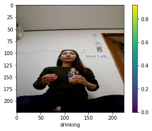

[figure not shown]

```python
#%run -i 'image_classification.py'
import matplotlib.pyplot as plt
plt.figure()
plt.imshow(train_images[0])
plt.xlabel(class_names.get(train_labels[0]))
plt.colorbar()
plt.grid(False)

plt.figure(figsize=(10,10))
for i in range(25):
    plt.subplot(5,5,i+1)
    plt.xticks([])
    plt.yticks([])
    plt.grid(False)
    plt.imshow(train_images[i], cmap=plt.cm.binary)
    plt.xlabel(class_names.get(train_labels[i]))

# TensorFlow and tf.keras
import tensorflow as tf
from tensorflow import keras
model = keras.Sequential([
    keras.layers.Flatten(input_shape=(224, 224,3)),
    keras.layers.Dense(128, activation=tf.nn.relu),
    keras.layers.Dense(10, activation=tf.nn.softmax)
])

model.compile(optimizer=tf.train.AdamOptimizer(),
              loss='sparse_categorical_crossentropy',
              metrics=['accuracy'])

model.fit(train_images, train_labels, epochs=50)

test_loss, test_acc = model.evaluate(test_images, test_labels)

print('Test accuracy:', test_acc)

predictions = model.predict(test_images)
```

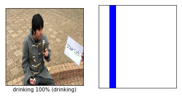

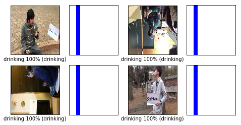

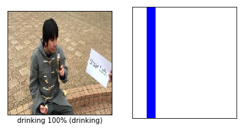

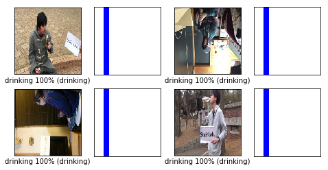

```python
def plot_image(i, predictions_array, true_label, img):
    predictions_array, true_label, img = predictions_array[i], true_label[i], img[i]
    plt.grid(False)
    plt.xticks([])
    plt.yticks([])

    plt.imshow(img, cmap=plt.cm.binary)
    predicted_label = np.argmax(predictions_array)
    if predicted_label == true_label:
        color = 'blue'
    else:
        color = 'red'

    plt.xlabel("{} {:2.0f}% ({})".format(class_names.get(predicted_label),100*np.max(predictions_array),class_names.get(true_label),color=color))

def plot_value_array(i, predictions_array, true_label):
    predictions_array, true_label = predictions_array[i], true_label[i]
    plt.grid(False)
    plt.xticks([])
    plt.yticks([])
    thisplot = plt.bar(range(10), predictions_array, color="#777777")
    plt.ylim([0, 1])
    predicted_label = np.argmax(predictions_array)

    thisplot[predicted_label].set_color('red')
    thisplot[true_label].set_color('blue')

i = 0
plt.figure(figsize=(6,3))
plt.subplot(1,2,1)
plot_image(i, predictions, test_labels, test_images)
plt.subplot(1,2,2)
plot_value_array(i, predictions,  test_labels)

# Plot the first X test images, their predicted label, and the true label
# Color correct predictions in blue, incorrect predictions in red
num_rows = 2
num_cols = 2
num_images = num_rows*num_cols
plt.figure(figsize=(2*2*num_cols, 2*num_rows))
for i in range(num_images):
  plt.subplot(num_rows, 2*num_cols, 2*i+1)
  plot_image(i, predictions, test_labels, test_images)
  plt.subplot(num_rows, 2*num_cols, 2*i+2)
  plot_value_array(i, predictions, test_labels)

i = 0
plt.figure(figsize=(6,3))
plt.subplot(1,2,1)
plot_image(i, predictions, test_labels, test_images)
plt.subplot(1,2,2)
plot_value_array(i, predictions,  test_labels)

# Plot the first X test images, their predicted label, and the true label
# Color correct predictions in blue, incorrect predictions in red
num_rows = 2
num_cols = 2
num_images = num_rows*num_cols
plt.figure(figsize=(2*2*num_cols, 2*num_rows))
for i in range(num_images):
  plt.subplot(num_rows, 2*num_cols, 2*i+1)
  plot_image(i, predictions, test_labels, test_images)
  plt.subplot(num_rows, 2*num_cols, 2*i+2)
  plot_value_array(i, predictions, test_labels)
```